# ESM 204: HW4

Patrick Pelegri-O’Day

5/18/2022

### Initial note

- No explanatory text is provided beyond what is explicitly asked for in the homework.
- Organized code and explanation of work is provided in the folded code chunks.

```r
damages_df <- read_csv(here("data", "damages.csv")) %>%
  clean_names()
warming_df <- read_csv(here('data', 'warming.csv')) %>%
  clean_names() %>%
  select(-x1)
```

### Question 1

```r
# Create vector of squared temperature for quadratic model
damages_df$warming2 <- damages_df$warming^2

# Define quadratic model for climate damages with 0 intercept
damages_lm <- lm(damages ~ 0 + warming + warming2, data = damages_df)

# Predict damages
damages_predict <- predict(damages_lm)

# Add predicted values to damages_df
damages_df <- damages_df %>%
  mutate(predicted_damages = damages_predict)

# The in-line text being called is:
# $y$ = `r damages_lm$coefficients[1]`$x$ + `r damages_lm$coefficients[2]`$x^2$.
```

A quadratic function relating damages to temperature is $y$ = -1.0595301^{12}$x$ + 1.9409276^{13}$x^2$.

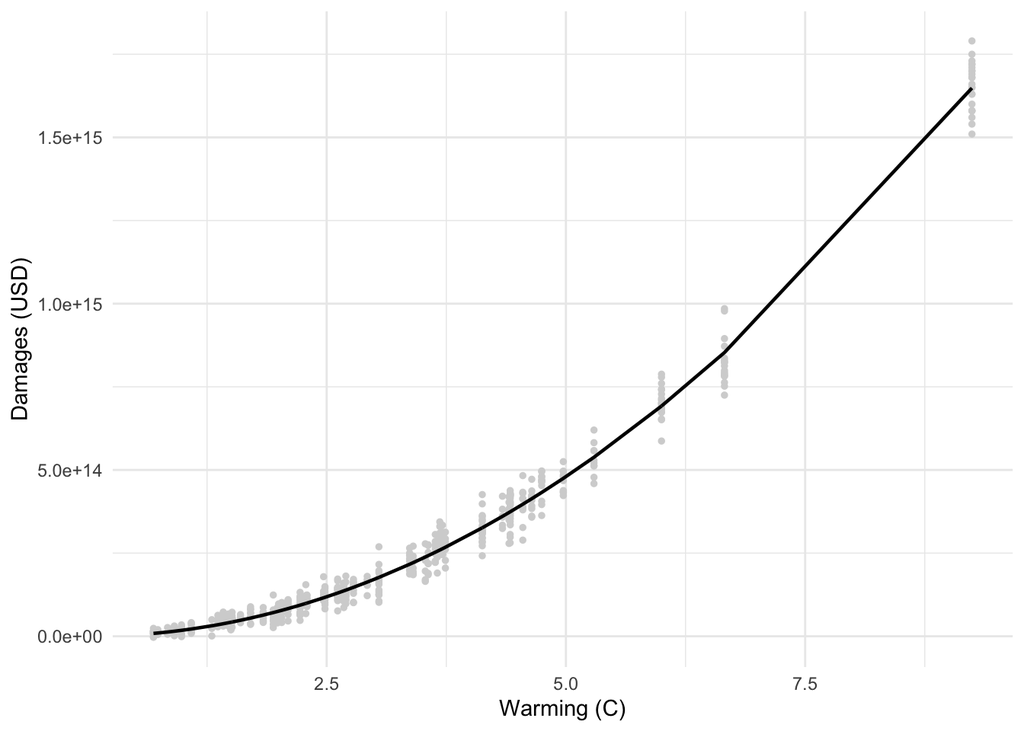

```r
# Plot predicted damages
ggplot(data = damages_df, aes(x = warming)) +
  geom_point(aes(y = damages), size = 1, color = 'gray83') +
  geom_line(aes(y = predicted_damages), size = 0.8, color = 'black') +
  theme_minimal() +
  labs(x = 'Warming (C)', y = 'Damages (USD)')
```

**Figure 1.** Estimated damages (USD) per unit of additional warming (Celsius) using a quadratic regression.

### Question 2

```r
# Create damages function
damages_func <- function(temp){
  damages = damages_lm$coefficients[1]*(temp) + damages_lm$coefficients[2]*((temp)^2)
  return(damages)
}
```

```r
# PREP FOR Q2 PLOTS

# Create columns of damages for baseline and pulse based on damages function calculated above
warming_df <- warming_df %>%
  mutate(damages_baseline = damages_func(warming_baseline)) %>%
  mutate(damages_pulse = damages_func(warming_pulse))

# Create column of additional damages from the pulse
warming_df <- warming_df %>%
  mutate(damages_addtl = damages_pulse - damages_baseline)

# Create column of additional damages from the pulse *per ton of CO2*
warming_df <- warming_df %>%
  mutate(damages_addtl_perton = (damages_pulse - damages_baseline)/(35*10^9))
```

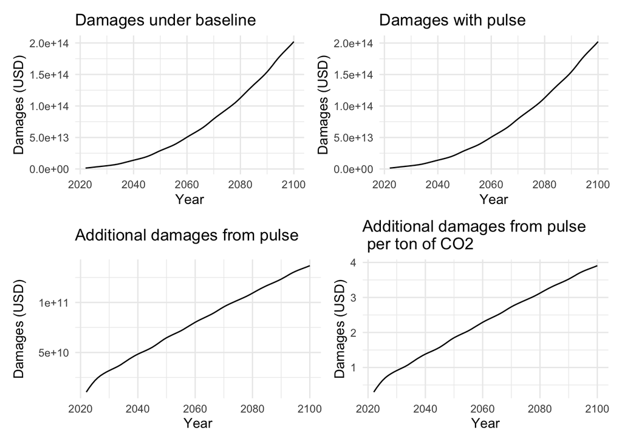

```r
# Q2 plots

# Plot of damages under baseline
baseline_dmg_plot <- ggplot(warming_df, aes(x = year, y = damages_baseline)) +
  geom_line() +
  theme_minimal() +
  labs(x = 'Year', y = 'Damages (USD)', title = 'Damages under baseline')

# Plot of damages under pulse
pulse_dmg_plot <- ggplot(warming_df, aes(x = year, y = damages_pulse)) +
  geom_line() +
  theme_minimal() +
  labs(x = 'Year', y = 'Damages (USD)', title = 'Damages with pulse')

# Plot of additional damages from pulse
addtl_dmg_plot <- ggplot(warming_df, aes(x = year, y = damages_addtl)) +
  geom_line() +
  theme_minimal() +
  labs(x = 'Year', y = 'Damages (USD)', title = 'Additional damages from pulse')

# Plot of additional damages from pulse per ton of CO2
addtl_dmg_perton_plot <- ggplot(warming_df, aes(x = year, y = damages_addtl_perton)) +
  geom_line() +
  theme_minimal() +
  labs(x = 'Year', y = 'Damages (USD)', title = 'Additional damages from pulse \n per ton of CO2')

q2_plots <- (baseline_dmg_plot + pulse_dmg_plot)/(addtl_dmg_plot + addtl_dmg_perton_plot)
q2_plots
```

**Figure 2.** Estimation of climate damages under different scenarios.

### Question 3

```r
# BUILD UP TO DF OF SCC & DISCOUNT RATES

# Create function of damages in present value based on year based on warming_df
addtl_dmg_pv_func <- function(addtl_dmg, r){
  addtl_dmg_pv = sum(addtl_dmg/((1+r)^c(1:length(addtl_dmg))))
  return(addtl_dmg_pv)
}

# Define terms for use in function above
addtl_dmg <- warming_df$damages_addtl_perton
r <- seq(0, 0.1, 0.005) # Calculate for r (discount rate) values from 0 to 10% in 0.5% increments
scc <- numeric() # Create empty vector for scc values to be put into

# Create vector scc that contains scc values at different discount rates
for(i in 1:length(r)){
  scc[i] <- addtl_dmg_pv_func(addtl_dmg,r[i])
}

# Make df of scc values and discount rates
scc_df <- data.frame(scc) %>%
  mutate(discount_rate_pct = 100*r)
```

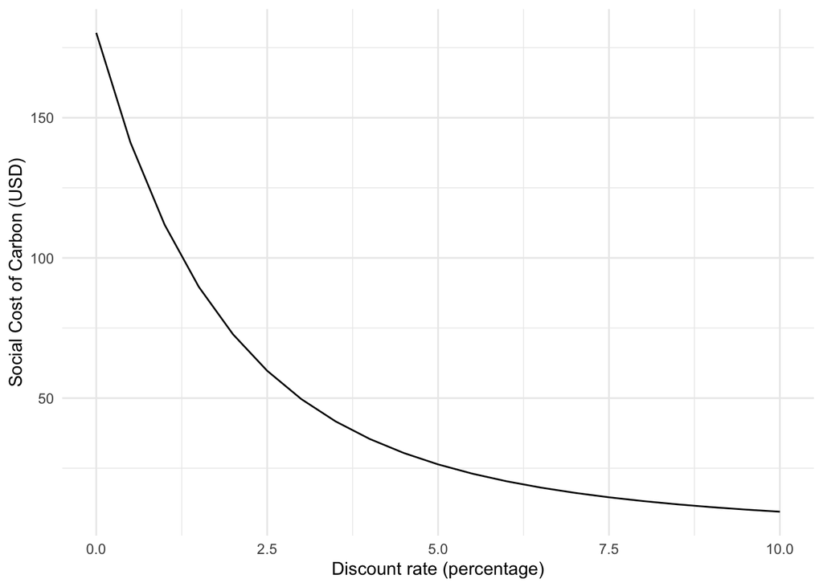

```r
# Plot scc against discount rate
ggplot(scc_df, aes(x = discount_rate_pct, y = scc)) +
  geom_line() +
  theme_minimal() +
  labs(x = 'Discount rate (percentage)', y = 'Social Cost of Carbon (USD)')
```

**Figure 3.** Social cost of carbon per discount rate.

**Explanation:** The SCC decreases as the discount rate increases because the SCC is based on the present value of future climate-related damages from greenhouse gas emissions. The higher the discount rate, the lower the cost of future damages in present-day terms.

### Question 4

The Ramsey Rule is r = p + ng. Given p = 0.001, n = 2, and g = 0.01: r = 0.021.

```r
scc_0.021dr <- addtl_dmg_pv_func(addtl_dmg, 0.021)

# The in-line text being called is:
# This corresponds to an SCC of `r round(scc_0.021dr, 1)`
```

This corresponds to an SCC of 69.9

Figure 3 is reproduced below with this point highlighted.

```r
# Create df with the Ramsey Rule point for plotting
ramsey_rule_v <- c(69.88626, 2.1)
ramsey_rule_df <- scc_df %>%
  rbind(ramsey_rule_v) %>%
  filter(discount_rate_pct == 2.1)
```

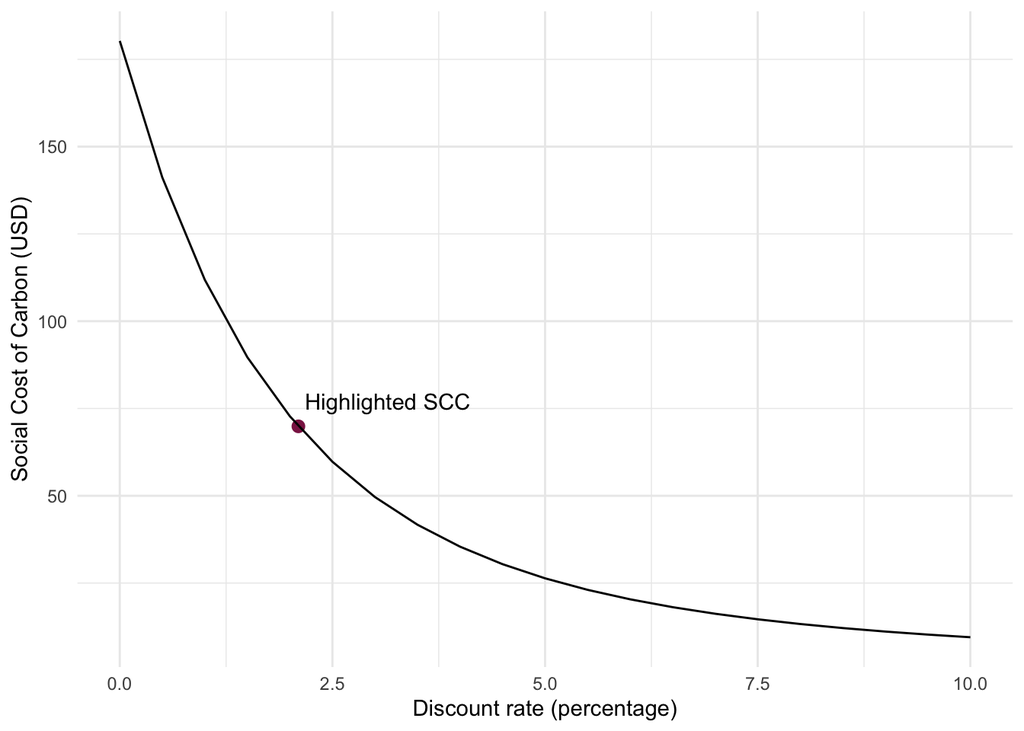

```r
# Plot scc against discount rate
ggplot() +
  geom_point(data = ramsey_rule_df,
             aes(x = discount_rate_pct, y = scc),
             color = 'violetred4',
             size = 2.5) +
 annotate("text", x = 3.15, y = 77, label = "Highlighted SCC") +
 geom_line(data = scc_df,
           aes(x = discount_rate_pct, y = scc)) +
  theme_minimal() +
  labs(x = 'Discount rate (percentage)', y = 'Social Cost of Carbon (USD)')
```

**Figure 4.** Social cost of carbon (SCC) per discount rate, with the SCC for a discount rate based on the Ramsey Rule highlighted.

### Question 5

```r
# Create new damages columns that will be used for calculating present value of Policies A and B
warming_df <- warming_df %>%
  mutate(damages_baseline_1.5 = 1.5*damages_baseline,
         damages_baseline_b = ifelse(warming_baseline<1.28, damages_baseline, damages_baseline[29])) # I used 1.28 because the warming value for 2051 is 1.287 and we want to stop at 2050. 2050 is the 29th row of the df.
```

```r
# Create function to compare present value of climate policies
policy_compare_f <- function(dmg_v){
  pv <- sum(dmg_v/((1.02)^c(1:length(warming_df$dmg_v)))) # Note a discount rate of 0.02 is used
  return(pv)
}

### Calculations to be done in-line
#     - Policy A: 0.5 * sum of damages using baseline + 0.5 * 1.5(sum of damages using baseline)
#     - Policy B: sum of damages using modified baseline, where modified baseline uses 1.29 degrees after 2050

# Define present value of Policy A and Policy B as objects for reference in-line
a_pv <- 0.5*policy_compare_f(warming_df$damages_baseline) + 0.5*policy_compare_f(warming_df$damages_baseline_1.5)

b_pv <- policy_compare_f(warming_df$damages_baseline_b)
```

Given a risk neutral outlook, Policy A leads to an expected present value of climate damages up to 2100 of 6.8363997^{15}. Policy B has an expected present value of 1.7698708^{15}.

```r
# Create df for graphing cost comparison
policy_compare_df <- data.frame(matrix(ncol = 1, nrow = 79))

# Create column x (costs of Policy B) for graphing. I chose a range of values from 0 to 78 x 10^14 to show where Policy B becomes more expensive in present value than Policy A.
policy_compare_df$x = seq(0, 78*10^14, 10^14)

# Create column for Policy A cost and Policy B cost
policy_compare_df$A = 0.5*policy_compare_f(warming_df$damages_baseline) + 0.5*policy_compare_f(warming_df$damages_baseline_1.5) # column of Policy A costs

policy_compare_df$B = policy_compare_f(warming_df$damages_baseline_b) + policy_compare_df$x # column of Policy B costs

policy_compare_df <- policy_compare_df %>% # remove initial column and pivot longer for graphing
  select(x, A, B) %>%
  pivot_longer(A:B,
               names_to = 'policy',
               values_to = 'cost')
```

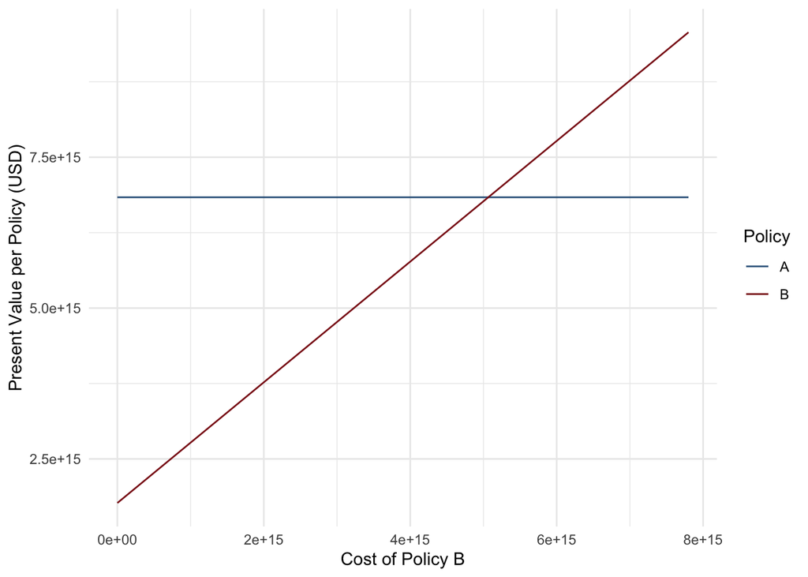

```r
# Graph x against cost of both policies
ggplot(policy_compare_df, aes(x = x, y = cost)) +
  geom_line(aes(color = policy)) +
  scale_color_manual(values = c('steelblue4', 'firebrick4')) +
  theme_minimal() +
  labs(x = 'Cost of Policy B', y = 'Present Value per Policy (USD)', color = 'Policy')
```

```r
# The in-line text called below the graph is `r a_pv - b_pv`
```

**Figure 5.** Comparing the societal cost of pursuing Climate Policy A vs. Climate Policy B as a function of the implementation cost of Climate Policy B.

Policy B leads to less societal cost considering climate damages and policy implementation costs when implementation costs are less than 5.0665289^{15}. Thus, I recommend Congress pursue Policy B if expected implementation costs of the policy are less than 5.0665289^{15}, and I recommend Congress pursue Policy A if expected implementation costs of Policy B are more than 5.0665289^{15}.

### Question 6

The greater Congress’s risk aversion, the more attractive Policy B will be. Risk aversion means a diminishing marginal utility of monetary payoff. This means that the utility from the high monetary payoff that has a 50% likelihood of occurring in Policy A will become relatively less valuable. The payoff from Policy B will also go down in terms of utility, but because B’s payoff is smaller than A’s payoff, the utility of Policy B’s payoff will decrease less in relative terms than the decrease in utility of Policy A’s payoff.

If Congress is risk averse, the implementation cost of Policy B that tips it from favorable to unfavorable is higher than if Congress is risk neutral. However, whether Congress pursues Policy A or Policy B still depends on the implementation cost of Policy B and Congress’s degree of risk aversion.